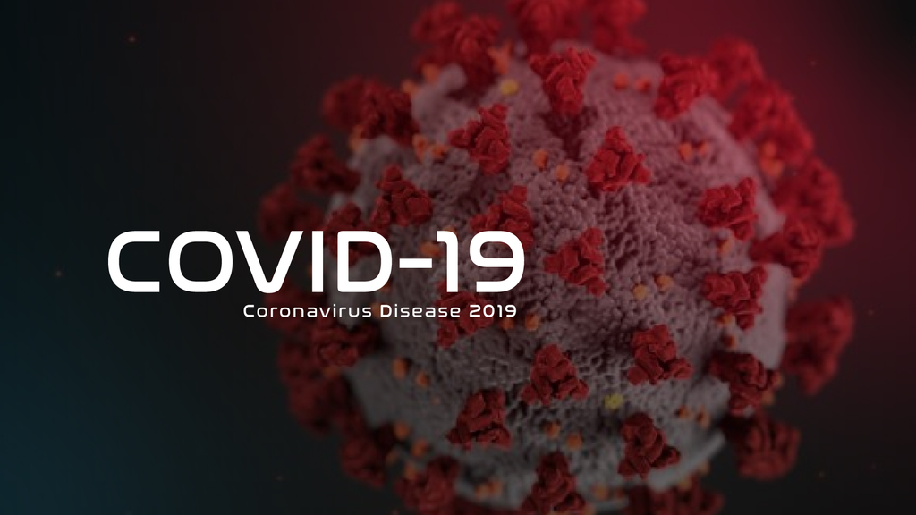

# Tracking: impact and forecast the counts of COVID-19 in India

### Definitions

**The world is facing humanity’s biggest crisis since World War II. Almost every country has been affected by the devastating Coronavirus disease (COVID-19). An outbreak from China has gone everywhere. In the last few months, Corona’s epicentre has been shifted from China to Europe to the United States. Till date, over 26 million people had been affected by COVID-19 and about 0.85 million people had died worldwide. Indirectly, billions of people have been suffering from the impact of the global pandemic of COVID-19.**

**INDEX**

1. Import Libraries
2. Read Data Sets
3. Data Preparation
4. Analysing the present condition in India
   - Confirmed Case
   - Recovered Case
   - Deceased
5. COVID-19 cases in affected State/Union Territories
6. Confirmed vs Recovered
7. Confirmed vs Recovered vs Deceased
8. Visualising the spread geographically
9. Why Prophet
10. Count forecasting using Prophet

### 1. Import Libraries

```python
#import library
import pandas as pd
import matplotlib.pyplot as plt
import seaborn as sns
from matplotlib import style
%matplotlib inline
import plotly.express as px
import plotly.graph_objects as go
import folium
import numpy as np
```

### 2. Read Data Sets

```python
#Read Data
df=pd.read_csv('https://api.covid19india.org/csv/latest/state_wise.csv')

coordinates = pd.read_excel("Indian Coordinates.xlsx")
df_full = pd.merge(coordinates,df,on="State")

df_time_series=pd.read_csv('https://api.covid19india.org/csv/latest/case_time_series.csv')
```

### 3. Data Preparation

```python
#Data Preparation
#Drop unwanted columns
df.drop(['Migrated_Other','Last_Updated_Time','Migrated_Other','Delta_Confirmed',
       'Delta_Recovered', 'Delta_Deaths', 'State_Notes'],axis = 1,inplace= True)

#Remove unwanted rows
df = df[(df.State != 'Total')& (df.State != 'State Unassigned')]

#Sort Dataframe by Confirmed Cases
df.sort_values(by='Confirmed',inplace=True,ascending=False)

#Date Colum fix
df_time_series['Year']='2020'
df_time_series["Date"] = df_time_series['Date'] + df_time_series['Year']

df_time_series['Date']=pd.to_datetime(df_time_series['Date'], format='%d %B %Y')

df_time_series.drop(['Year'],axis=1,inplace=True)
```

### 4. Analysing the present condition in India

The first COVID-19 case was reported on 30th January 2020 when a student arrived Kerala from Wuhan. Just in next 2 days, Kerela reported 2 more cases. For almost a month, no new cases were reported in India, however, on 2nd March 2020, five new cases of corona virus were reported in Kerala again and since then the cases have been rising affecting the states and UT. Here is a brief timeline of the cases in India.

```python
#latest 10 days counts
df_time_series[['Date','Daily Confirmed','Daily Recovered','Daily Deceased']].tail(10)
```

|  | Date | Daily Confirmed | Daily Recovered | Daily Deceased |
| --- | --- | --- | --- | --- |
| 207 | 2020-08-24 | 59696 | 66305 | 854 |
| 208 | 2020-08-25 | 66873 | 64151 | 1066 |
| 209 | 2020-08-26 | 75995 | 56191 | 1017 |
| 210 | 2020-08-27 | 76827 | 59620 | 1066 |
| 211 | 2020-08-28 | 76657 | 64475 | 1019 |
| 212 | 2020-08-29 | 78479 | 64982 | 943 |
| 213 | 2020-08-30 | 79461 | 60422 | 960 |
| 214 | 2020-08-31 | 68766 | 64435 | 816 |
| 215 | 2020-09-01 | 78168 | 62145 | 1027 |
| 216 | 2020-09-02 | 82860 | 67874 | 1026 |

### 4.1 Confirmed Case

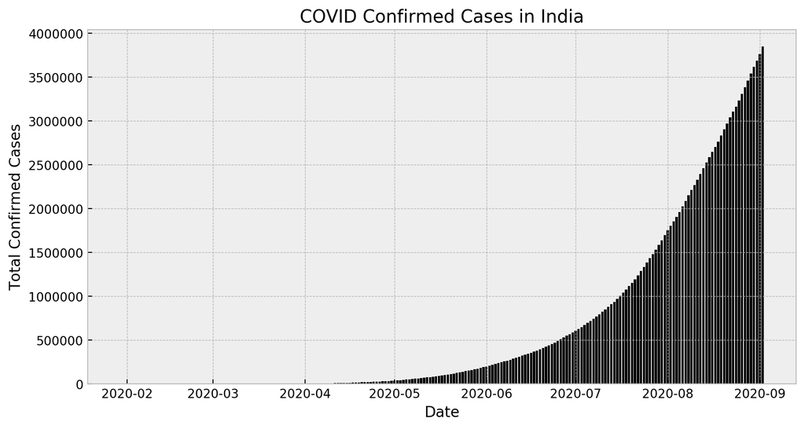

```python
fig = plt.figure(figsize=(10,5),dpi=200)
axes = fig.add_axes([0.1,0.1,0.8,0.8])
axes.bar(df_time_series["Date"],df_time_series["Total Confirmed"],color='black')
axes.set_xlabel("Date")
axes.set_ylabel("Total Confirmed Cases")
axes.set_title("COVID Confirmed Cases in India")
```

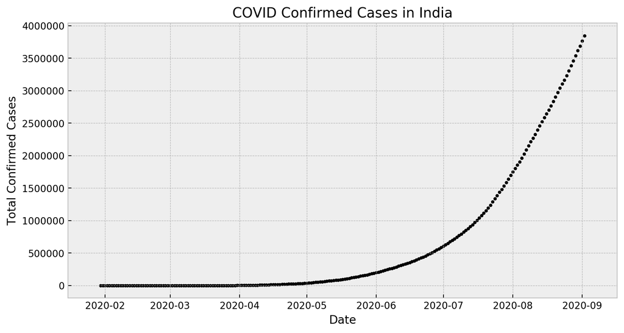

```python
fig = plt.figure(figsize=(10,5),dpi=200)
axes = fig.add_axes([0.1,0.1,0.8,0.8])
axes.scatter(df_time_series["Date"],df_time_series["Total Confirmed"],color='black',marker=".")
axes.set_xlabel("Date")
axes.set_ylabel("Total Confirmed Cases")
axes.set_title("COVID Confirmed Cases in India")
```

### 4.2 Recovered Case

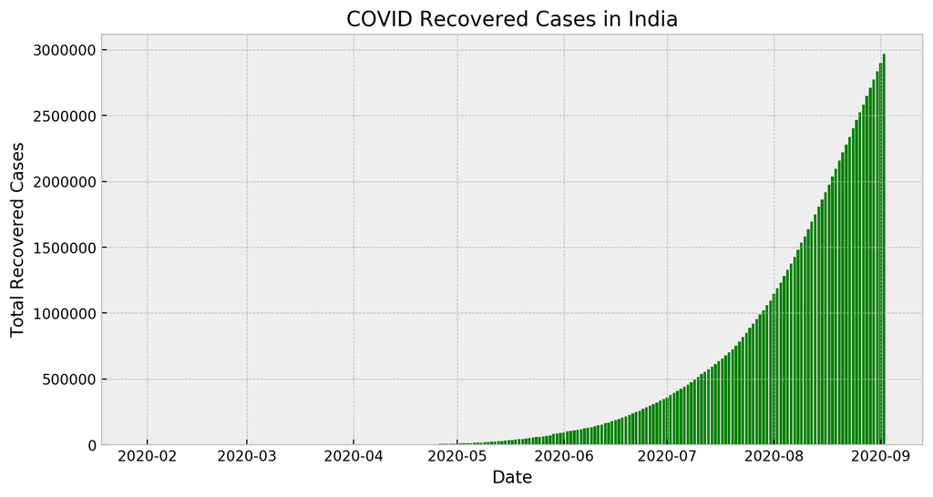

```python
fig = plt.figure(figsize=(10,5),dpi=200)
axes = fig.add_axes([0.1,0.1,0.8,0.8])
axes.bar(df_time_series["Date"],df_time_series["Total Recovered"],color='green')
axes.set_xlabel("Date")
axes.set_ylabel("Total Recovered Cases")
axes.set_title("COVID Recovered Cases in India")
```

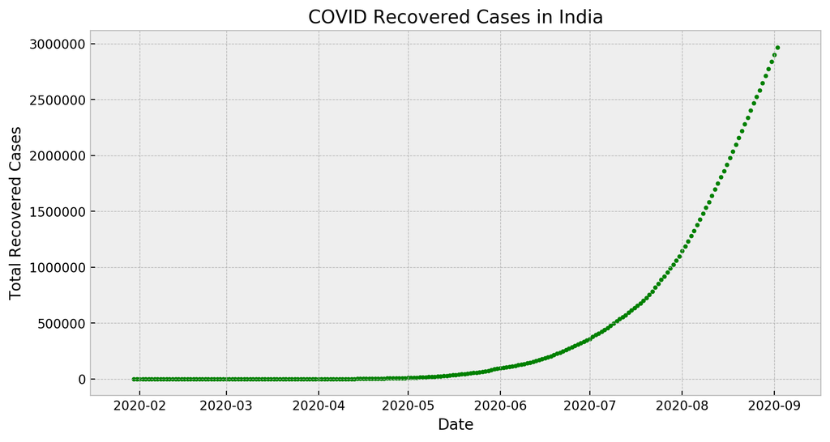

```python
fig = plt.figure(figsize=(10,5),dpi=200)
axes = fig.add_axes([0.1,0.1,0.8,0.8])
axes.scatter(df_time_series["Date"],df_time_series["Total Recovered"],color='green',marker=".")
axes.set_xlabel("Date")
axes.set_ylabel("Total Recovered Cases")
axes.set_title("COVID Recovered Cases in India")
```

### 4.3 Deceased Case

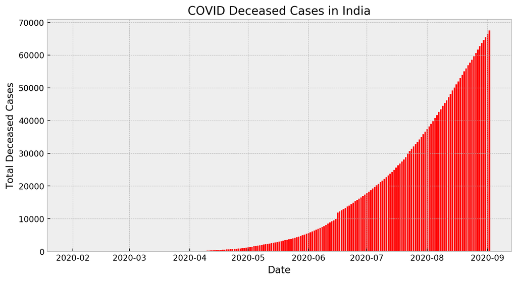

```python
fig = plt.figure(figsize=(10,5),dpi=200)
axes = fig.add_axes([0.1,0.1,0.8,0.8])
axes.bar(df_time_series["Date"],df_time_series["Total Deceased"],color='red')
axes.set_xlabel("Date")
axes.set_ylabel("Total Deceased Cases")
axes.set_title("COVID Deceased Cases in India")
```

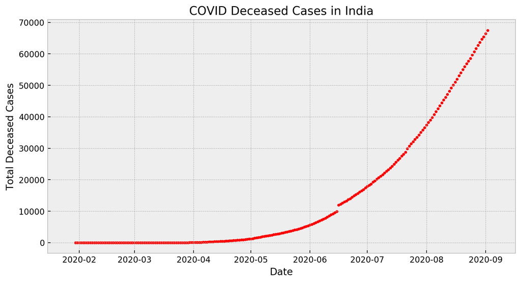

```python
fig = plt.figure(figsize=(10,5),dpi=200)
axes = fig.add_axes([0.1,0.1,0.8,0.8])
axes.scatter(df_time_series["Date"],df_time_series["Total Deceased"],color='red',marker=".")
axes.set_xlabel("Date")
axes.set_ylabel("Total Deceased Cases")
axes.set_title("COVID Deceased Cases in India")
```

### 5. COVID-19 cases in affected State/Union Territories

```python
df.style.background_gradient(cmap='Reds')
```

|  | State | Confirmed | Recovered | Deaths | Active | State_code |
| --- | --- | --- | --- | --- | --- | --- |
| 1 | Maharashtra | 843844 | 612484 | 25586 | 205428 | MH |
| 3 | Andhra Pradesh | 465730 | 357829 | 4200 | 103701 | AP |
| 2 | Tamil Nadu | 445851 | 386173 | 7608 | 52070 | TN |
| 4 | Karnataka | 370206 | 268035 | 6054 | 96098 | KA |
| 6 | Uttar Pradesh | 247101 | 185812 | 3691 | 57598 | UP |
| 5 | Delhi | 182306 | 160114 | 4500 | 17692 | DL |
| 7 | West Bengal | 171681 | 144248 | 3394 | 24039 | WB |
| 8 | Bihar | 142156 | 124976 | 728 | 16451 | BR |
| 9 | Telangana | 133406 | 100013 | 856 | 32537 | TG |
| 11 | Assam | 115280 | 88727 | 323 | 26227 | AS |
| 13 | Odisha | 113411 | 87351 | 575 | 25485 | OR |
| 10 | Gujarat | 100375 | 81280 | 3062 | 16033 | GJ |
| 12 | Rajasthan | 86227 | 71220 | 1095 | 13912 | RJ |
| 16 | Kerala | 79626 | 57728 | 316 | 21517 | KL |
| 14 | Haryana | 70099 | 55889 | 740 | 13470 | HR |
| 15 | Madhya Pradesh | 68586 | 52215 | 1483 | 14888 | MP |
| 17 | Punjab | 58515 | 41271 | 1690 | 15554 | PB |
| 19 | Jharkhand | 44862 | 29747 | 438 | 14677 | JH |
| 18 | Jammu and Kashmir | 39943 | 30759 | 743 | 8441 | JK |
| 20 | Chhattisgarh | 36520 | 18950 | 312 | 17258 | CT |
| 21 | Uttarakhand | 22180 | 14945 | 300 | 6871 | UT |
| 22 | Goa | 19355 | 14361 | 212 | 4782 | GA |
| 24 | Puducherry | 15581 | 10279 | 260 | 5042 | PY |
| 23 | Tripura | 13309 | 8033 | 126 | 5130 | TR |
| 26 | Himachal Pradesh | 6615 | 4813 | 47 | 1708 | HP |
| 25 | Manipur | 6609 | 4774 | 32 | 1803 | MN |
| 31 | Chandigarh | 5065 | 2883 | 63 | 2116 | CH |
| 28 | Arunachal Pradesh | 4360 | 3075 | 7 | 1278 | AR |
| 27 | Nagaland | 4066 | 3314 | 8 | 732 | NL |
| 29 | Andaman and Nicobar Islands | 3186 | 2758 | 47 | 381 | AN |
| 30 | Ladakh | 2785 | 2007 | 35 | 743 | LA |
| 33 | Meghalaya | 2517 | 1318 | 13 | 1186 | ML |
| 32 | Dadra and Nagar Haveli and Daman and Diu | 2459 | 2159 | 2 | 278 | DN |
| 34 | Sikkim | 1738 | 1304 | 5 | 429 | SK |
| 35 | Mizoram | 1040 | 669 | 0 | 371 | MZ |
| 37 | Lakshadweep | 0 | 0 | 0 | 0 | LD |

**Visualization Inference:**

- Maharashtra has the highest number of confirmed cases followed by Andhra Pradesh.
- Lakshadweep has ZERO no of covid cases.
- Maharashtra, Andhra Pradesh and Tamil Nadu are TOP 3 states with maximum number of confirmed cases.
- Maharashtra, Tamil Nadu and Andhra Pradesh are TOP 3 states with maximum number of recovery cases.
- Maharashtra, Tamil Nadu and Karnataka are TOP 3 states with maximum number of deaths.

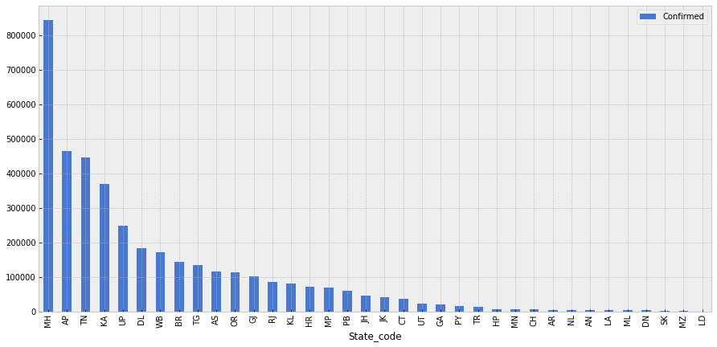

```python
plt.style.use("bmh")
plt.rcParams['figure.figsize'] = 15,7
df.plot(kind="bar",x="State_code",y="Confirmed",color='b')

plt.show()
```

### 6. Confirmed vs Recovered

[output not shown]

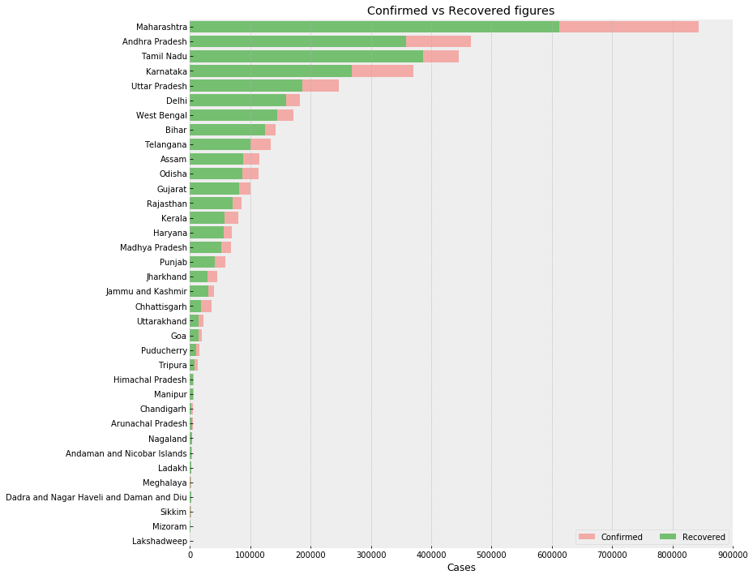

```python
f,ax = plt.subplots(figsize=(12,12))
data = df_full[['State',"Confirmed","Recovered","Deaths"]]
data.sort_values('Confirmed',ascending=False,inplace=True)
sns.set_color_codes("pastel")
sns.barplot(x="Confirmed", y="State", data=data, label="Confirmed",color="r")

sns.set_color_codes("muted")
sns.barplot(x="Recovered", y="State", data=data, label="Recovered",color="g")

ax.legend(ncol=2, loc="lower right", frameon=True)
ax.set(xlim=(0,900000), ylabel="", xlabel="Cases",title='Confirmed vs Recovered figures')
sns.despine(left=True, bottom=True)
```

### 7. Confirmed vs Recovered vs Deceased counts

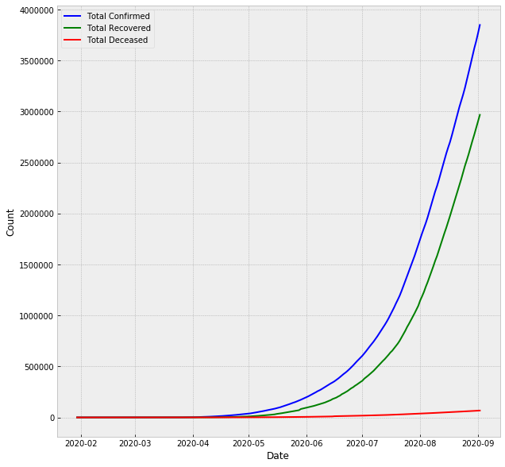

```python
plt.figure(figsize= (10  , 10 ))
plt.plot(df_time_series['Date'],df_time_series['Total Confirmed'], color='blue', label = "Total Confirmed")
plt.plot(df_time_series['Date'],df_time_series['Total Recovered'], color='green', label = "Total Recovered")
plt.plot(df_time_series['Date'],df_time_series['Total Deceased'], color='red', label = "Total Deceased")


plt.xlabel("Date")
plt.ylabel('Count')
plt.legend()
plt.grid(linestyle = "--")
```

### 8. Visualising the spread geographically

```python
map = folium.Map(location=[20,70],zoom_start=5, tiles="CartoDB Dark_Matter")
for lat,long,value,name in zip(df_full['Latitude'], df_full['Longitude'], df_full['Confirmed'], df_full['State']):
  folium.CircleMarker([lat,long], radius=value*0.00003, popup=('<strong>State</strong>: '+str(name).capitalize()+'<br>'+'<strong>Total Cases</strong>'+str(value)+'<br>'),
  color = 'red', fill_color='red',fill_opacity=0.3).add_to(map)
map
```

[interactive chart not shown]

### 9. Why Prophet

Prophet is open source software released by Facebook’s Core Data Science team. It is available for download on CRAN and PyPI.

Prophet is a procedure for forecasting time series data based on an additive model where non-linear trends are fit with yearly, weekly, and daily seasonality, plus holiday effects. It works best with time series that have strong seasonal effects and several seasons of historical data. Prophet is robust to missing data and shifts in the trend, and typically handles outliers well.

- Accurate and fast: Prophet is used in many applications across Facebook for producing reliable forecasts for planning and goal setting. Facebook finds it to perform better than any other approach in the majority of cases. It fit models in Stan so that you get forecasts in just a few seconds.
- Fully automatic: Get a reasonable forecast on messy data with no manual effort. Prophet is robust to outliers, missing data, and dramatic changes in your time series.
- Tunable forecasts: The Prophet procedure includes many possibilities for users to tweak and adjust forecasts. You can use human-interpretable parameters to improve your forecast by adding your domain knowledge
- Available in R or Python: Facebook has implemented the Prophet procedure in R and Python. Both of them share the same underlying Stan code for fitting. You can use whatever language you’re comfortable with to get forecasts.

**Prophet is able to detect the uncertainty but what trend changes should we expect moving forward? It’s impossible to know for sure, so we do the most reasonable thing we can, and we assume that the future will see similar trend changes as the history.**

### 10. Count Forecasting

**Forecasting confirm case using Prophet (1 month)**

```python
confirmed=df_time_series[['Date','Daily Confirmed']]
confirmed.columns = ['ds','y']
```

```python
from fbprophet import Prophet

model = Prophet(interval_width=0.96)
model.fit(confirmed)
future = model.make_future_dataframe(periods=30)
```

```
INFO:fbprophet:Disabling yearly seasonality. Run prophet with yearly_seasonality=True to override this.
INFO:fbprophet:Disabling daily seasonality. Run prophet with daily_seasonality=True to override this.
```

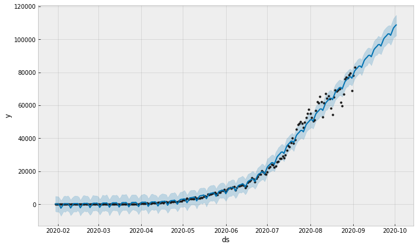

```python
forecast = model.predict(future)
forecast_plot = model.plot(forecast)
```

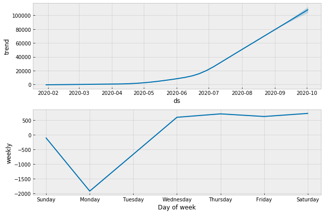

```python
components_plot = model.plot_components(forecast)
```

**Forecasting recover case using Prophet (1 month)**

```python
recovered=df_time_series[['Date','Total Recovered']]
recovered.columns = ['ds','y']
```

```python
from fbprophet import Prophet
model = Prophet(interval_width=0.96)
model.fit(recovered)
future = model.make_future_dataframe(periods=30)
```

```
INFO:fbprophet:Disabling yearly seasonality. Run prophet with yearly_seasonality=True to override this.
INFO:fbprophet:Disabling daily seasonality. Run prophet with daily_seasonality=True to override this.
```

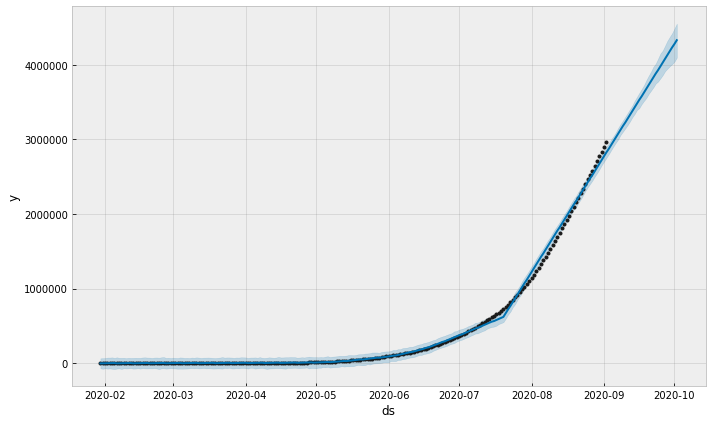

```python
forecast = model.predict(future)
forecast_plot = model.plot(forecast)
```

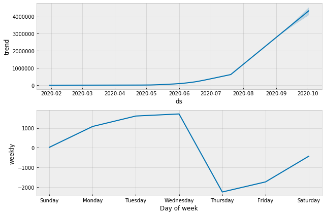

```python
components_plot = model.plot_components(forecast)
```

**Forecasting death case using Prophet (1 month)**

```python
deceased=df_time_series[['Date','Total Deceased']]
deceased.columns = ['ds','y']
```

```python
from fbprophet import Prophet

model = Prophet(interval_width=0.96)
model.fit(deceased)
future = model.make_future_dataframe(periods=30)
```

```
INFO:fbprophet:Disabling yearly seasonality. Run prophet with yearly_seasonality=True to override this.
INFO:fbprophet:Disabling daily seasonality. Run prophet with daily_seasonality=True to override this.
```

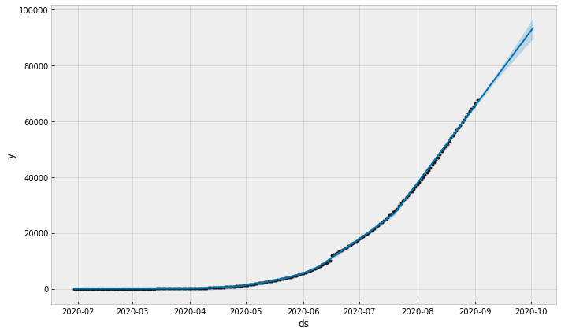

```python
forecast = model.predict(future)
forecast_plot = model.plot(forecast)
```

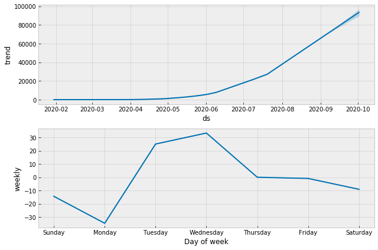

```python
components_plot = model.plot_components(forecast)
```

```python
!ipython nbconvert 20200903_COVID.ipynb
import os
os.rename(r'20200903_COVID.html',r'index.html')
```

[output not shown]